# VC data, first sim results

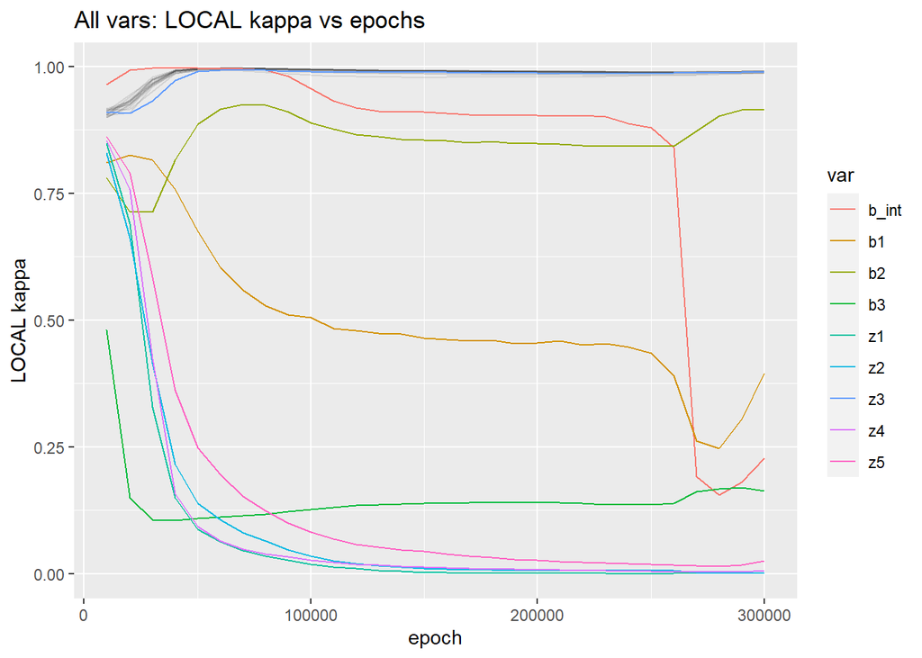

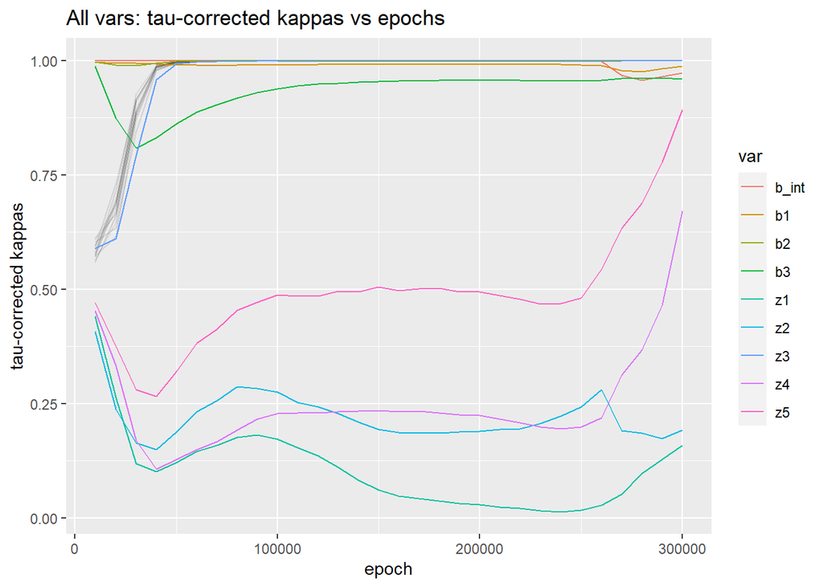

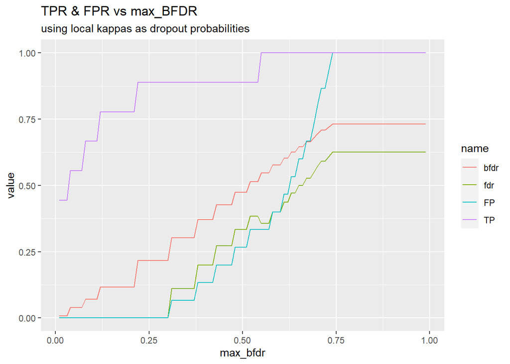

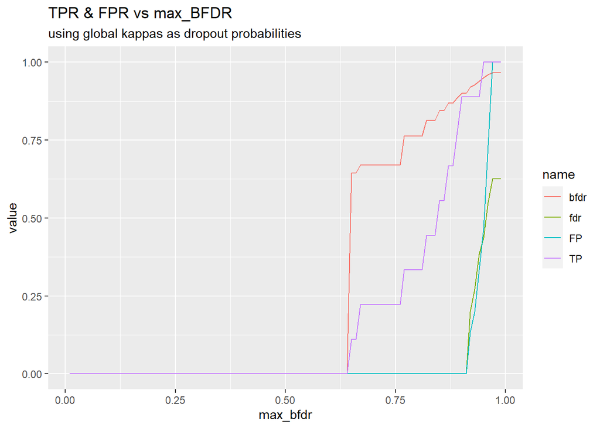

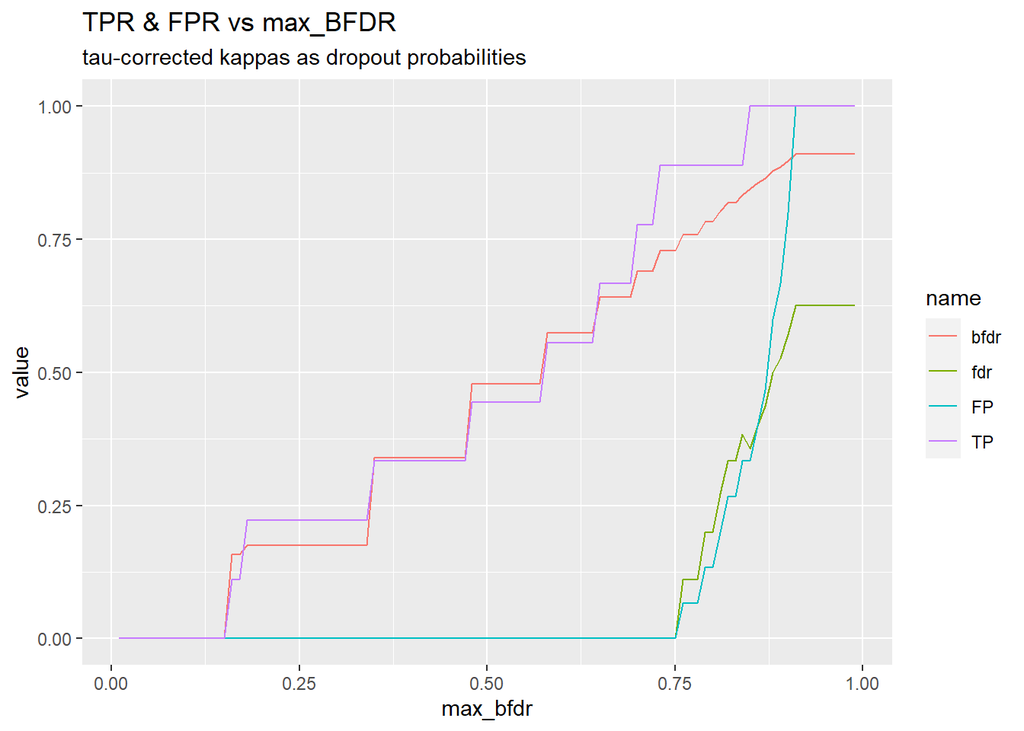

#### sim 2

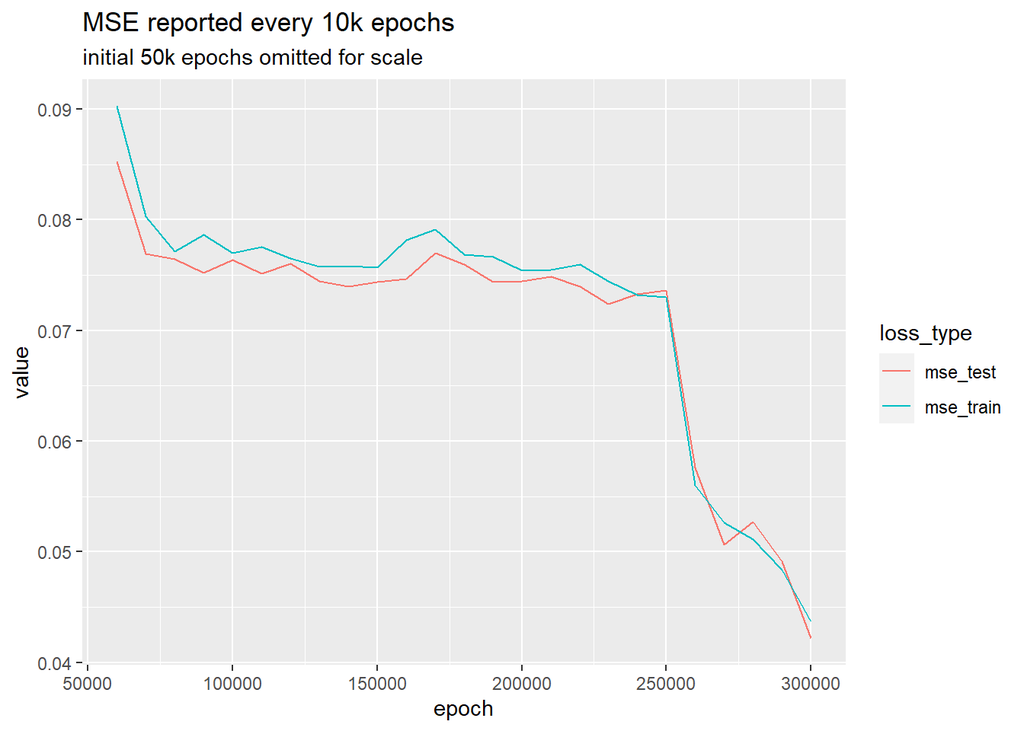

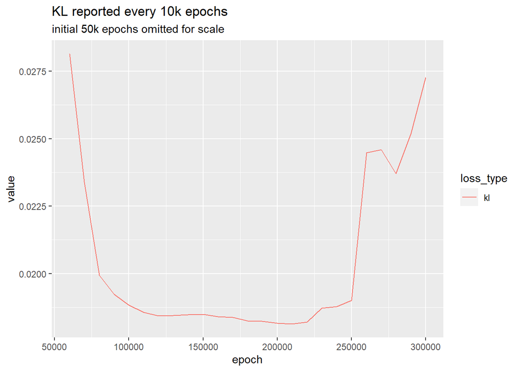

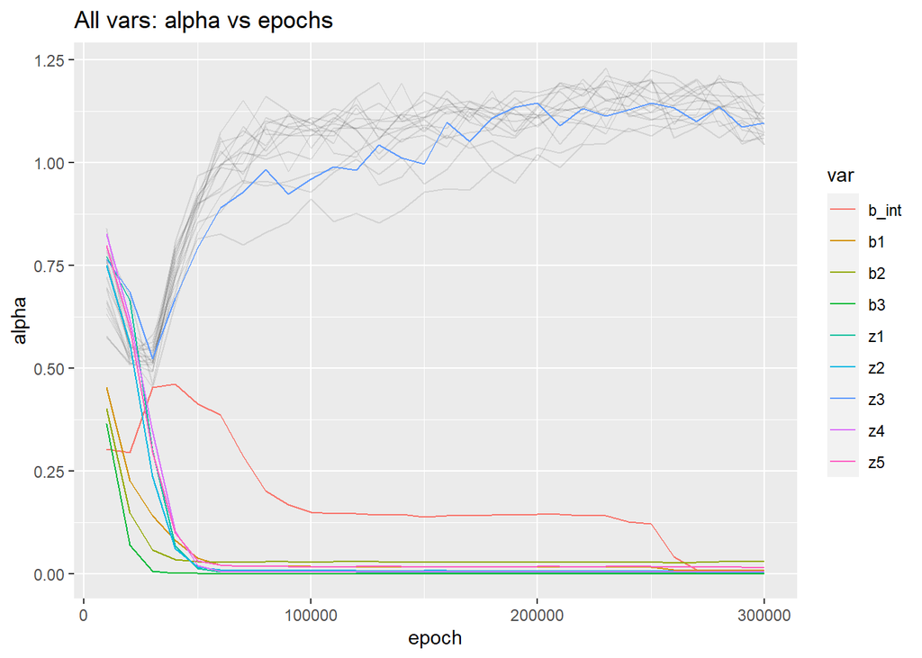

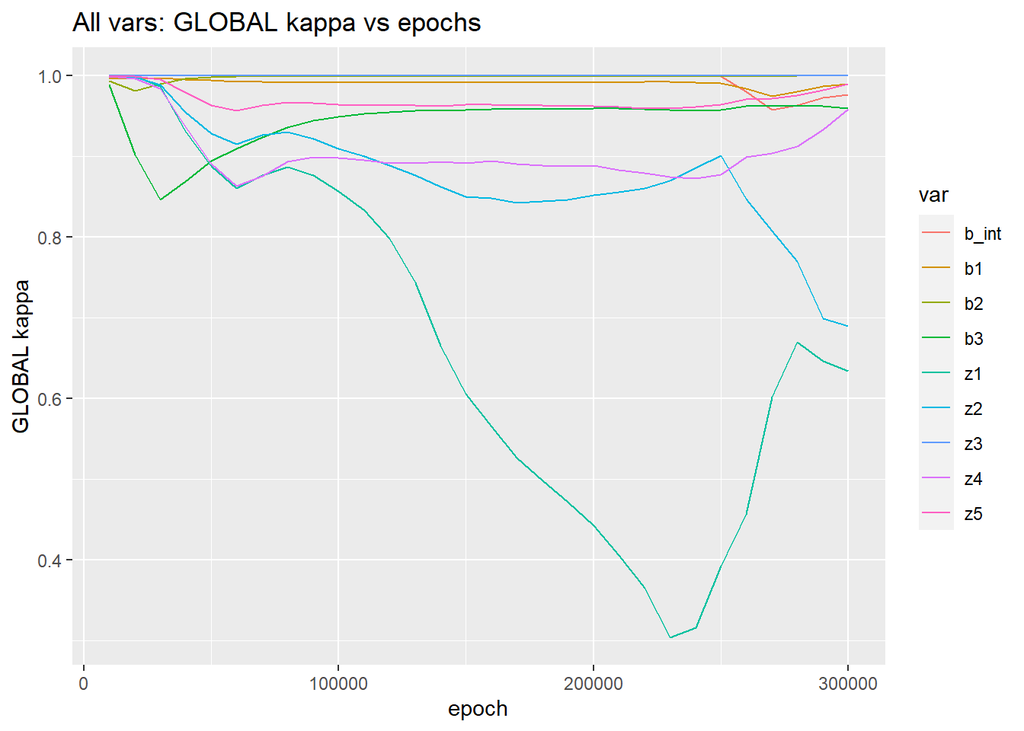

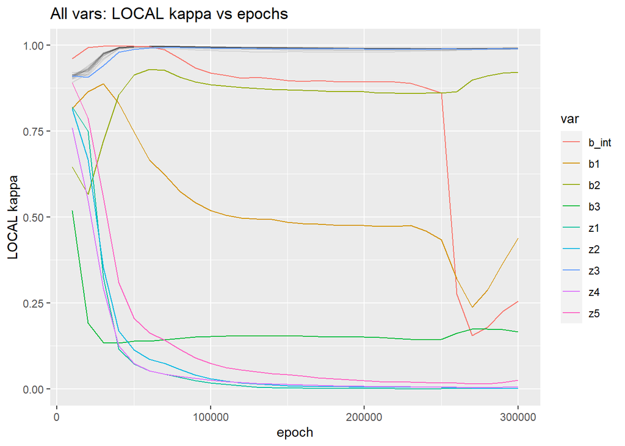

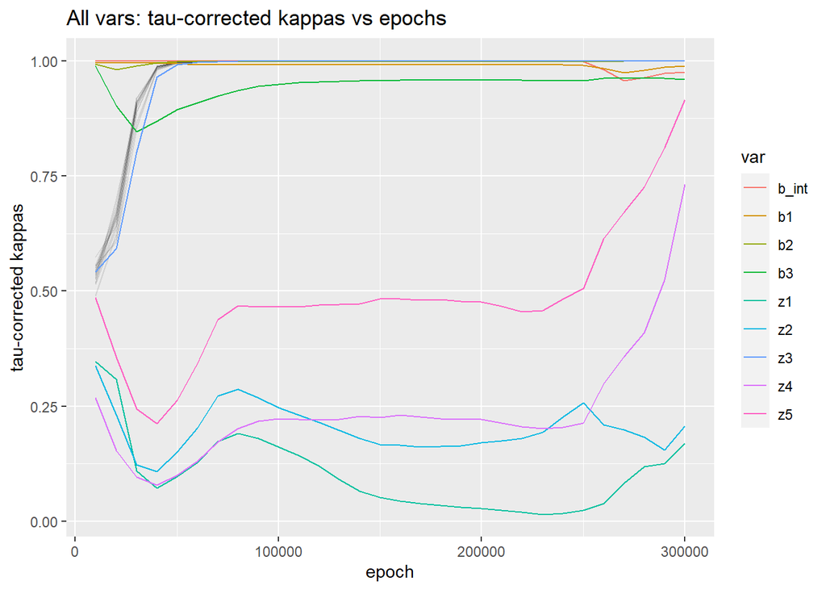

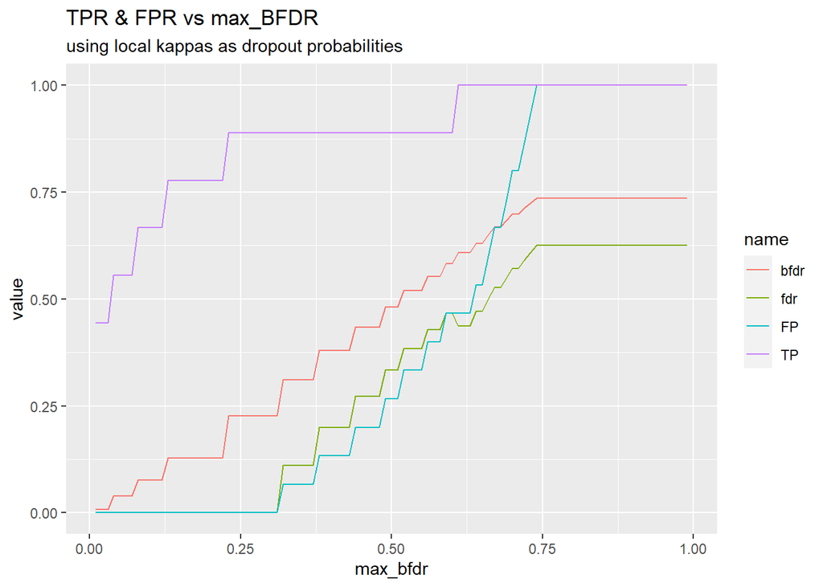

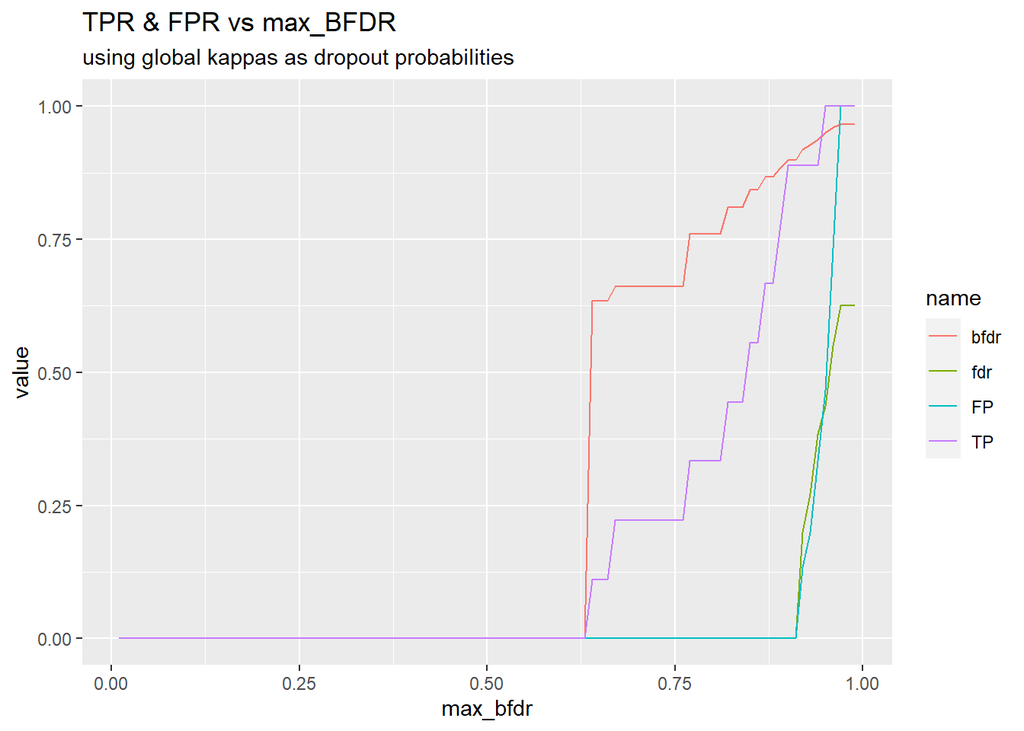

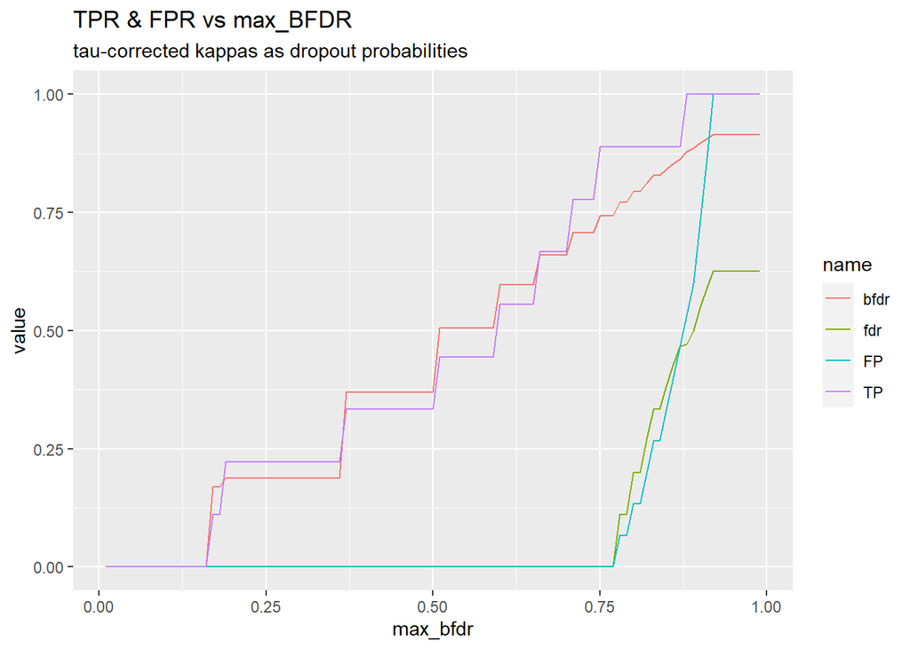

### comments

MSE/loss plots look **nowhere near convergence.** Actually kind of heartening that maybe it can do better, but how long will we need to train? Increase the learning rate a bunch.

## all agnostic 3L VC sim

- data: R = 20, p = 3, n = 10k, noise = 0
- model: 3 regular hshoe layers + vc layer
- (agnostic) prior tau_R (used in first layer): `sim_res$sim_params$prior_tau_R`
- (agnostic) prior tau_p (used in last layer): `sim_res$sim_params$prior_tau_p`
- 2 hidden layers, 8 and 16 units;
- $\tau_0$ agnostic for all.

```r
nn_mod$children
```

```
## $fc1
## An `nn_module` containing 420 parameters.
##
## -- Parameters ------------------------------------------------------------------
## * sa_mu: Float [1:1]
## * sa_logvar: Float [1:1]
## * sb_mu: Float [1:1]
## * sb_logvar: Float [1:1]
## * atilde_mu: Float [1:20]
## * atilde_logvar: Float [1:20]
## * btilde_mu: Float [1:20]
## * btilde_logvar: Float [1:20]
## * weight_mu: Float [1:8, 1:20]
## * weight_logvar: Float [1:8, 1:20]
## * bias_mu: Float [1:8]
## * bias_logvar: Float [1:8]
##
## $fc2
## An `nn_module` containing 324 parameters.
##
## -- Parameters ------------------------------------------------------------------
## * sa_mu: Float [1:1]
## * sa_logvar: Float [1:1]
## * sb_mu: Float [1:1]
## * sb_logvar: Float [1:1]
## * atilde_mu: Float [1:8]
## * atilde_logvar: Float [1:8]
## * btilde_mu: Float [1:8]
## * btilde_logvar: Float [1:8]
## * weight_mu: Float [1:16, 1:8]
## * weight_logvar: Float [1:16, 1:8]
## * bias_mu: Float [1:16]
## * bias_logvar: Float [1:16]
##
## $fc3
## An `nn_module` containing 204 parameters.
##
## -- Parameters ------------------------------------------------------------------
## * sa_mu: Float [1:1]
## * sa_logvar: Float [1:1]
```

[output cut: 8 more lines]

```
## * bias_mu: Float [1:4]
## * bias_logvar: Float [1:4]
##
## $vc
## An `nn_module` containing 20 parameters.
##
## -- Parameters ------------------------------------------------------------------
## * sa_mu: Float [1:1]
## * sa_logvar: Float [1:1]
## * sb_mu: Float [1:1]
## * sb_logvar: Float [1:1]
## * atilde_mu: Float [1:4]
## * atilde_logvar: Float [1:4]
## * btilde_mu: Float [1:4]
## * btilde_logvar: Float [1:4]
```

### results

```r
load(resfile_vc3l[1])
nn_mod <- torch_load(modfile_vc3l[1])
```

#### sim 1

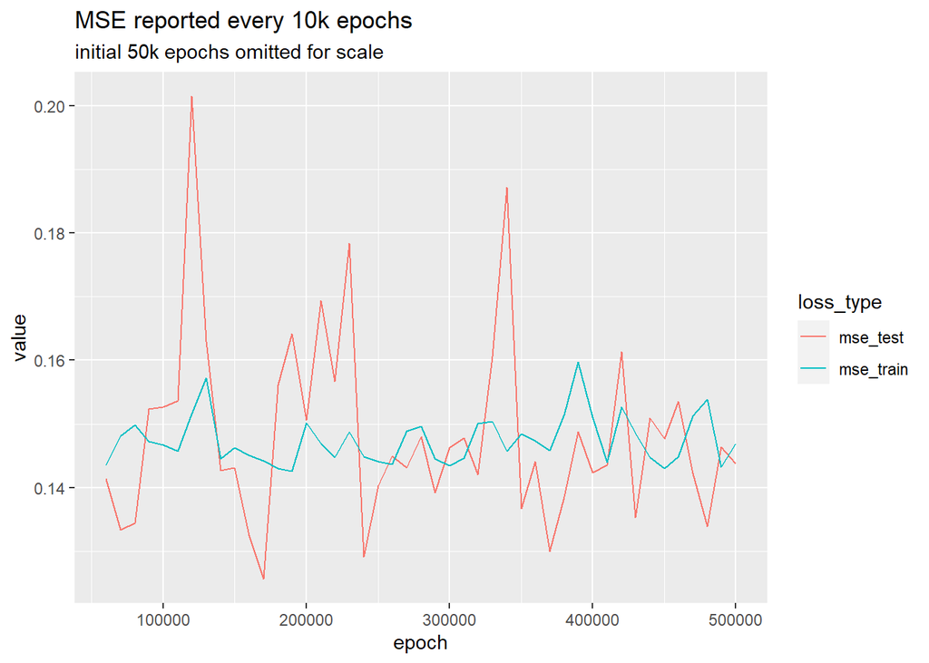

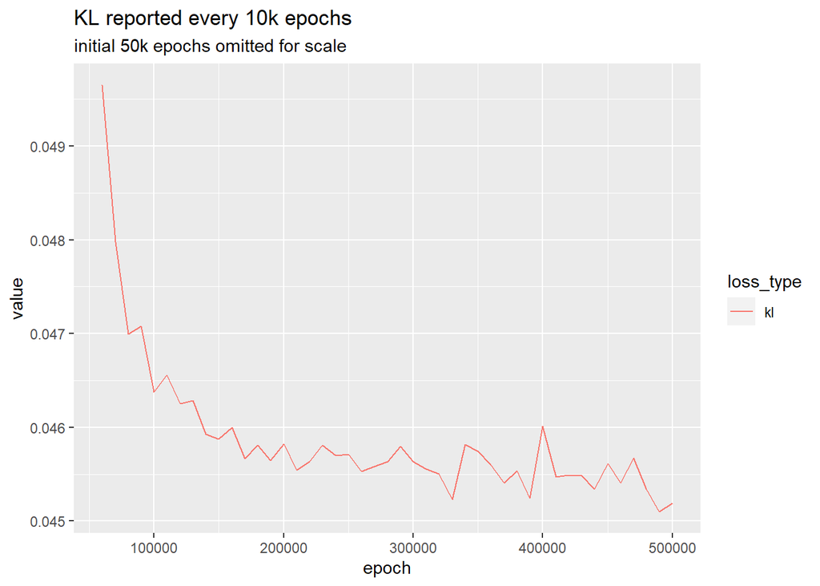

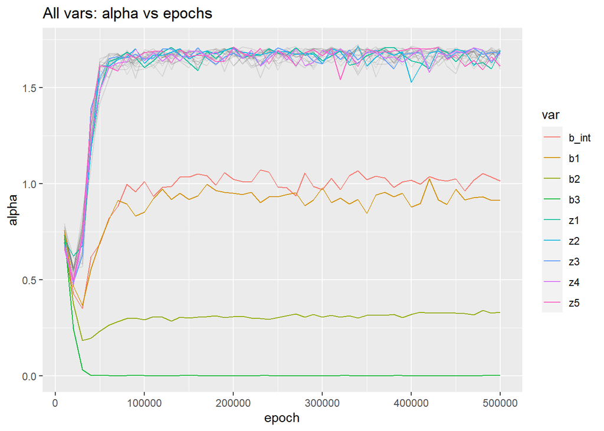

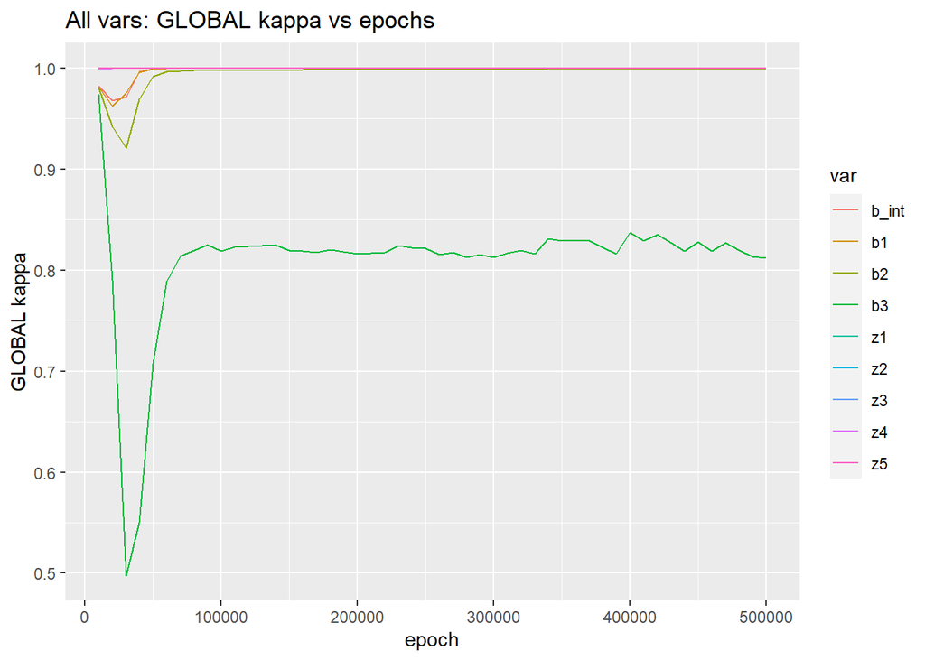

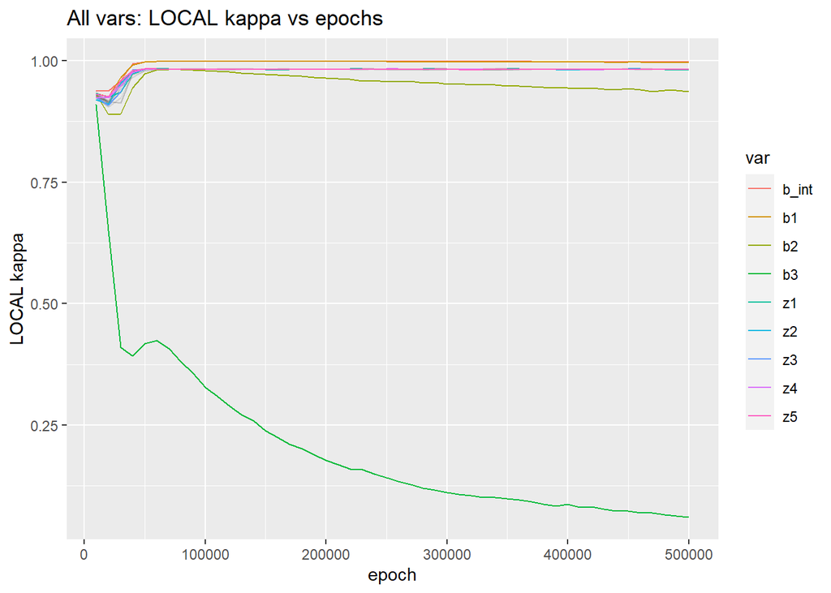

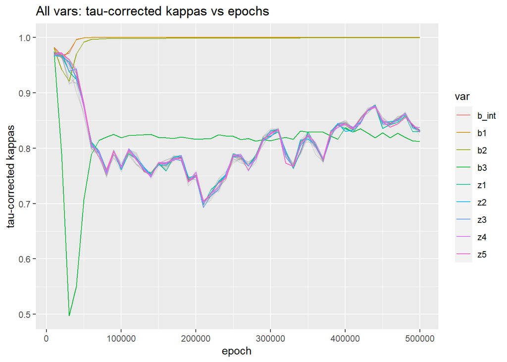

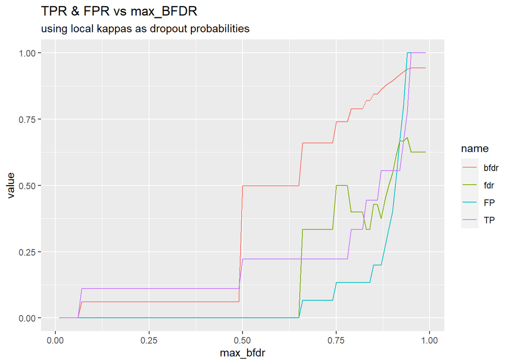

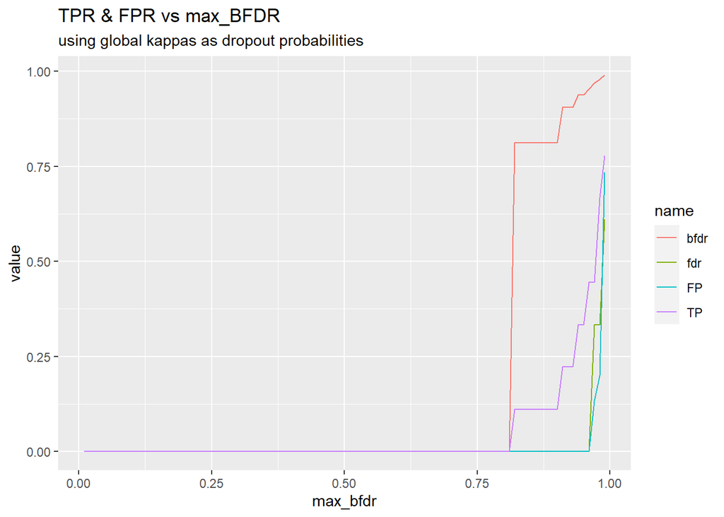

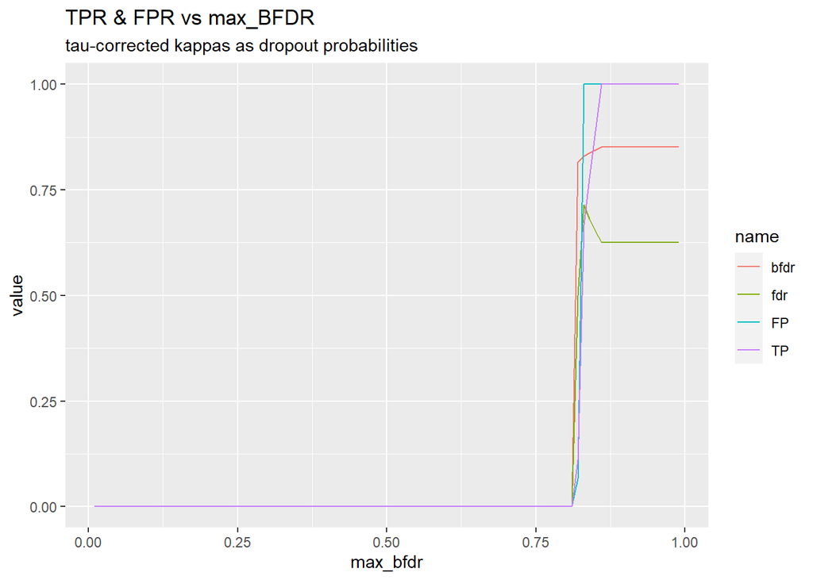

### comments

Terrible. First layer (look at $Z$-related $\kappa$’s) doesn’t seem to really be learning.